# Exercise 4_1: OSM Data

Introduction to Geospatial Techniques for Social Scientists in R

Author

Stefan Jünger & Dennis Abel

### Exercises

**🏋 Exercise 1**

Pick a city of the world to your liking and retrieve its bounding box. Then plot it: What do you see?

**💡 Tip**

The function you may search for is part of the `osmdata` package. Have a look at the slides.

**🏋 Exercise 2**

Please choose a couple of building types you are interested in and set them as key and value pairs. You can find a list of building types in the [Overpass API documentation](https://wiki.openstreetmap.org/wiki/Key:building). But don’t forget to set the timeout query parameters using the `osmdata::opq()` function first.

**💡 Tip**

First, specify the bounding box like before; second, the query parameters; and third, the key and value pairs. Try using a pipe workflow, as it makes it easier.

**🏋 Exercise 3**

Download the data using the `osmadata::osmdata_sf()` function and extract only the polygons.

**💡 Tip**

The downloaded data is a list. The polygons are a named list element that you can extract with its name `osm_polygons`, just like a variable in a data table.

**🏋 Exercise 4**

Take some time to browse through the data. Depending on your chosen building type, you may find some interesting information. You can also plot the data you have just downloaded.

**💡 Tip**

You may consider converting the data into a tibble using `tibble::as_tibble()` and maybe a `sf::st_as_sf()` afterward for a nicer browsing experience.

### Solutions

**✅ Solution 1**

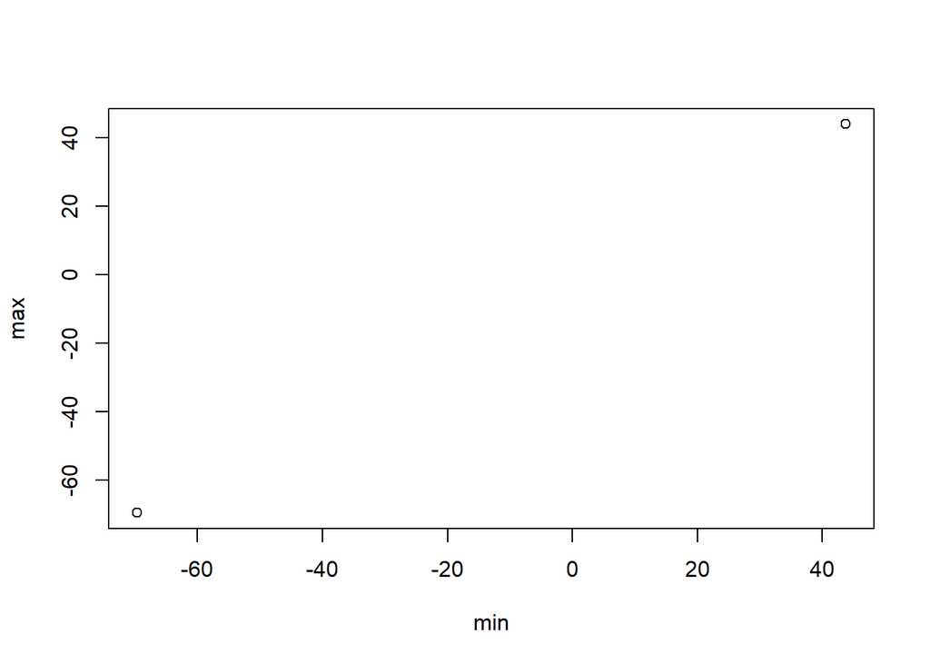

```r
boothbay <- osmdata::getbb("Boothbay")

plot(boothbay)
```

```r
# We see two points, which build the extremes of the bounding box.
```

**✅ Solution 2**

```r
boothbay <-
  osmdata::getbb("Boothbay") |>
  osmdata::opq(timeout = 25*100) |>
  osmdata::add_osm_feature(
    key = "building",
    value = c("house", "residential", "apartments", "detached", "bungalow")
  )
```

**✅ Solution 3**

```r
boothbay <-
  osmdata::getbb("Boothbay") |>
  osmdata::opq(timeout = 25*100) |>
  osmdata::add_osm_feature(
    key = "building",
    value = c("house", "residential", "apartments", "detached", "bungalow")
  ) |>
  osmdata::osmdata_sf()

boothbay <- boothbay$osm_polygons
```

**✅ Solution 4**

```r
library(tmap)

boothbay <-
  boothbay |>
  tibble::as_tibble() |>
  sf::st_as_sf()

boothbay
```

```
Simple feature collection with 86 features and 21 fields
Geometry type: POLYGON
Dimension:     XY
Bounding box:  xmin: -69.68898 ymin: 43.79767 xmax: -69.51428 ymax: 43.9415
Geodetic CRS:  WGS 84
# A tibble: 86 × 22
   osm_id    name     `addr:city` `addr:county` `addr:hamlet` `addr:housenumber`
   <chr>     <chr>    <chr>       <chr>         <chr>         <chr>
 1 234813057 <NA>     <NA>        <NA>          <NA>          <NA>
 2 234813059 <NA>     <NA>        <NA>          <NA>          <NA>
 3 234813061 <NA>     <NA>        <NA>          <NA>          <NA>
 4 234813064 <NA>     <NA>        <NA>          <NA>          <NA>
 5 307439615 <NA>     Boothbay    <NA>          <NA>          92
 6 307439619 <NA>     Boothbay    <NA>          <NA>          24
 7 307439630 <NA>     Boothbay    <NA>          <NA>          11
 8 426703460 South G… <NA>        <NA>          <NA>          <NA>
 9 426703464 Bath Ca… <NA>        <NA>          <NA>          <NA>
10 517083614 Chimney… <NA>        <NA>          <NA>          <NA>
# ℹ 76 more rows
# ℹ 16 more variables: `addr:locality` <chr>, `addr:postcode` <chr>,
#   `addr:state` <chr>, `addr:street` <chr>, building <chr>,
#   `building:colour` <chr>, `building:levels` <chr>,
#   `building:material` <chr>, ele <chr>, house <chr>, layer <chr>,
#   `roof:colour` <chr>, source <chr>, wikidata <chr>, wikipedia <chr>,
#   geometry <POLYGON [°]>
```

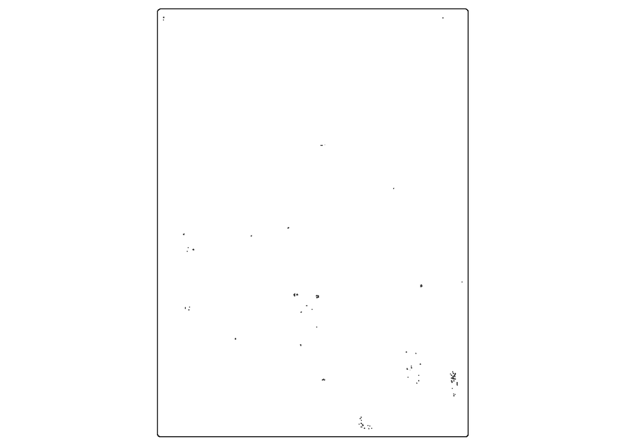

```r
# tmap_mode(("view"))

tm_shape(boothbay) +
  tm_polygons()
```